# REPRODUCIBLE RESEARCH PROJECT

Nomthunzi Moyo and Ange Simone Rehema

5/27/2021

# BACKGROUND AND JUSTIFICATION OF INITIAL STUDY

The aim of the original paper was to identify externally induced factors which can affect an individuals’ level of education. For investigation the study includes Econometric analysis and its tools such as ordered probit model that takes education level as the dependent variable and the factors that influences this variable as predictors.

The analysis was based on a CollegeDistance dataset that is on AER library.

This dataset comes from a survey conducted by the Department of Education in 1980 and it includes students from about 1100 high schools. It contains 4739 observations of 14 variables:

- Gender: factor indicating gender (male or female);
- Ethnicity: factor indicating the race and it takes 3 different values: afam if African American, Hispanic or other;
- Score: it’s the score obtained in the base year composite test;
- Fcollege: it’s a dummy variable that reply to the question “Is the father a college graduate?”;
- Mcollege: it’s the same as previous variable, but it refers to the mother;
- Home: dummy variable about the ownership of their own home;
- Urban: factor that reply to the question “Is the school in an urban area?”;
- Unemp: unemployment rate in 1980;
- Wage: hourly wage in manufacturing industry in 1980;
- Distance: distance in 10 miles from 4-year college;
- Tuition: average 4-year college tuition (in 1000 USD);
- Education: number of years of education. In particular, the ones with 12 years are all members of senior classes, with 13 are students with vocational degrees, AA degrees are assigned 14 years, BA degrees are assigned 16 years, 17 years to students with some graduate education and finally 18 years to those with a graduate degree;
- Income: dummy variable with value 1 if the family income is above USD 25000 per year and 0 otherwise;
- Region: factor indicating the region (West or other).

```r
data("CollegeDistance")
str(CollegeDistance)
```

```
## 'data.frame':    4739 obs. of  14 variables:
##  $ gender   : Factor w/ 2 levels "male","female": 1 2 1 1 2 1 2 2 1 2 ...
##  $ ethnicity: Factor w/ 3 levels "other","afam",..: 1 1 1 2 1 1 1 1 1 1 ...
##  $ score    : num  39.2 48.9 48.7 40.4 40.5 ...
##  $ fcollege : Factor w/ 2 levels "no","yes": 2 1 1 1 1 1 1 1 2 1 ...
##  $ mcollege : Factor w/ 2 levels "no","yes": 1 1 1 1 1 1 1 1 1 1 ...
##  $ home     : Factor w/ 2 levels "no","yes": 2 2 2 2 1 2 2 2 2 2 ...
##  $ urban    : Factor w/ 2 levels "no","yes": 2 2 2 2 2 2 1 1 2 2 ...
##  $ unemp    : num  6.2 6.2 6.2 6.2 5.6 ...
##  $ wage     : num  8.09 8.09 8.09 8.09 8.09 ...
##  $ distance : num  0.2 0.2 0.2 0.2 0.4 ...
##  $ tuition  : num  0.889 0.889 0.889 0.889 0.889 ...
##  $ education: num  12 12 12 12 13 12 13 15 13 15 ...
##  $ income   : Factor w/ 2 levels "low","high": 2 1 1 1 1 1 1 1 1 1 ...
##  $ region   : Factor w/ 2 levels "other","west": 1 1 1 1 1 1 1 1 1 1 ...
##  - attr(*, "datalabel")= chr ""
##  - attr(*, "time.stamp")= chr "25 Oct 2002 16:44"
##  - attr(*, "formats")= chr [1:14] "%9.0g" "%9.0g" "%9.0g" "%9.0g" ...
##  - attr(*, "types")= int [1:14] 102 102 102 102 102 102 102 102 102 102 ...
##  - attr(*, "val.labels")= chr [1:14] "" "" "" "" ...
##  - attr(*, "var.labels")= chr [1:14] "" "" "" "" ...
##  - attr(*, "version")= int 6
##  - attr(*, "label.table")=List of 14
##   ..$ : NULL
##   ..$ : NULL
##   ..$ : NULL
##   ..$ : NULL
##   ..$ : NULL
##   ..$ : NULL
##   ..$ : NULL
##   ..$ : NULL
##   ..$ : NULL
##   ..$ : NULL
##   ..$ : NULL
##   ..$ : NULL
##   ..$ : NULL
##   ..$ : NULL
```

```r
library("hrbrthemes")
library("dplyr")
library("AER")
library("sandwich")
library("zoo")
library("lmtest")
library("MASS")
library("pscl")
library("LogisticDx")
library("ucminf")
library("ordinal")
library("reshape")
library("generalhoslem")
library("oglmx")
library("aod")
library("brant")
library("ggplot2")
library("devtools")
library("usethis")
library("dplyr")
library("stargazer")
library("erer")
library("sjPlot")
library("glmx")
```

# DATA PREPARATION

To facilitate the analysis, the following data manipulation was made: -For the dependent variable education:level 18 has very few observations. To improve the analysis I will add it to level 17. Students with some graduate and those with graduate degree will be combined together. Also variable education was converted to factor and rename levels - 6 being the higher level of education. - A nonlinear variable was created.The variable square wage variable was added to model the effect a differing wages (There might be non linear relationship between education and wage/score). A positive effect of wage/score squared means that as people earn more the effect is stronger and vice-versa. As people earn more, they have enough for tuition and hence will continue studies. -An interaction variable was also created: Interaction occurs when the effect of one variable depends on another variable. An interaction between gender and scores will check if there exists differences between scores of male and female. First, let’s change levels of variable gender to a dummy numeric : 0 male and 1 female.

```
##
##   12   13   14   15   16   17   18
## 1832  613  518  556  907  256   57
```

```
##
##   12   13   14   15   16   17
## 1832  613  518  556  907  313
```

```
##
##    1    2    3    4    5    6
## 1832  613  518  556  907  313
```

```
##
##    0    1
## 2139 2600
```

Box plot of score per level in both genders

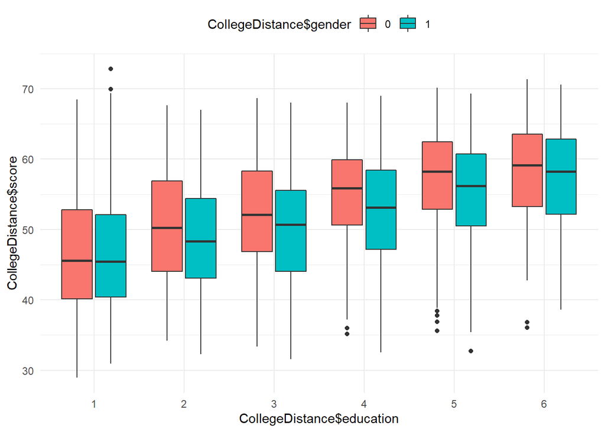

Existence of missing observations in all columns was also checked and the result below shows that there was no missing observations in the dataset.

```r
colSums(is.na(CollegeDistance)) %>%
  sort()
```

```
##    gender ethnicity     score  fcollege  mcollege      home     urban     unemp
##         0         0         0         0         0         0         0         0
##      wage  distance   tuition education    income    region     wage2   Scorgen
##         0         0         0         0         0         0         0         0
```

# MODEL SPECIFICATION

A probit and logit model was build taking education as dependent variable and the rest as predictors.

We first build a logit model.

```
## Call:
## polr(formula = education ~ ., data = CollegeDistance, Hess = TRUE,
##     method = "logistic")
##
## Coefficients:
##                      Value Std. Error t value
## gender1            0.81105   0.348909  2.3245
## ethnicityafam      0.43894   0.083396  5.2633
## ethnicityhispanic  0.39494   0.078138  5.0544
## score              0.12910   0.010881 11.8648
## fcollegeyes        0.59628   0.075801  7.8663
## mcollegeyes        0.44576   0.085361  5.2220
## homeyes            0.21526   0.074065  2.9063
## urbanyes           0.07837   0.068767  1.1397
## unemp              0.03748   0.010933  3.4285
## wage               0.19243   0.227252  0.8468
## distance          -0.04848   0.013385 -3.6220
## tuition           -0.22551   0.112414 -2.0061
## incomehigh         0.45361   0.064615  7.0203
## regionwest        -0.14225   0.085892 -1.6562
## wage2             -0.01257   0.011917 -1.0549
## Scorgen           -0.01216   0.006641 -1.8304
##
## Intercepts:
##     Value   Std. Error t value
## 1|2  6.7727  1.1293     5.9974
## 2|3  7.4392  1.1302     6.5824
## 3|4  8.0147  1.1312     7.0854
## 4|5  8.7082  1.1322     7.6914
## 5|6 10.5599  1.1346     9.3073
##
## Residual Deviance: 13859.27
## AIC: 13901.27
```

```
##
## z test of coefficients:
##
##                     Estimate Std. Error z value  Pr(>|z|)
## gender1            0.8110479  0.3489092  2.3245 0.0200974 *
## ethnicityafam      0.4389368  0.0833956  5.2633 1.415e-07 ***
## ethnicityhispanic  0.3949440  0.0781381  5.0544 4.317e-07 ***
## score              0.1290981  0.0108807 11.8648 < 2.2e-16 ***
## fcollegeyes        0.5962755  0.0758011  7.8663 3.652e-15 ***
## mcollegeyes        0.4457571  0.0853606  5.2220 1.770e-07 ***
## homeyes            0.2152575  0.0740647  2.9063 0.0036568 **
## urbanyes           0.0783720  0.0687666  1.1397 0.2544189
## unemp              0.0374841  0.0109332  3.4285 0.0006070 ***
## wage               0.1924286  0.2272520  0.8468 0.3971272
## distance          -0.0484817  0.0133852 -3.6220 0.0002923 ***
## tuition           -0.2255100  0.1124142 -2.0061 0.0448495 *
## incomehigh         0.4536146  0.0646149  7.0203 2.214e-12 ***
## regionwest        -0.1422511  0.0858917 -1.6562 0.0976878 .
## wage2             -0.0125711  0.0119167 -1.0549 0.2914633
## Scorgen           -0.0121560  0.0066412 -1.8304 0.0671898 .
## 1|2                6.7727474  1.1292835  5.9974 2.005e-09 ***
## 2|3                7.4392274  1.1301666  6.5824 4.629e-11 ***
## 3|4                8.0146937  1.1311617  7.0854 1.387e-12 ***
## 4|5                8.7081808  1.1321945  7.6914 1.455e-14 ***
## 5|6               10.5599342  1.1345863  9.3073 < 2.2e-16 ***
## ---
## Signif. codes:  0 '***' 0.001 '**' 0.01 '*' 0.05 '.' 0.1 ' ' 1
```

```
##
##  Hosmer and Lemeshow test (ordinal model)
##
## data:  CollegeDistance$education, fitted(elogit)
## X-squared = 38.349, df = 29, p-value = 0.1148
```

-The brant test was also used to if there is a need to use an advanced model.The Omnibus in the result is 0 which means that the proportional odds assumption is violated.

```
## ----------------------------------------------------
## Test for     X2  df  probability
## ----------------------------------------------------
## Omnibus          160.04  64  0
## gender1          3.17    4   0.53
## ethnicityafam        25.86   4   0
## ethnicityhispanic    6.06    4   0.19
## score            3.97    4   0.41
## fcollegeyes      9.89    4   0.04
## mcollegeyes      4.37    4   0.36
## homeyes          1.06    4   0.9
## urbanyes     2.82    4   0.59
## unemp            2.04    4   0.73
## wage         17.22   4   0
## distance     5.99    4   0.2
## tuition          5.8 4   0.21
## incomehigh       7.68    4   0.1
## regionwest       13.39   4   0.01
## wage2            17.48   4   0
## Scorgen          3.54    4   0.47
## ----------------------------------------------------
##
## H0: Parallel Regression Assumption holds
```

```
##                           X2 df  probability
## Omnibus           160.037691 64 3.465669e-10
## gender1             3.172579  4 5.293713e-01
## ethnicityafam      25.857312  4 3.381157e-05
## ethnicityhispanic   6.060881  4 1.946476e-01
## score               3.967006  4 4.104895e-01
## fcollegeyes         9.889729  4 4.232672e-02
## mcollegeyes         4.370068  4 3.582332e-01
## homeyes             1.063313  4 9.000485e-01
## urbanyes            2.818417  4 5.886578e-01
## unemp               2.038197  4 7.287333e-01
## wage               17.221750  4 1.750279e-03
## distance            5.986016  4 2.001950e-01
## tuition             5.803262  4 2.143304e-01
## incomehigh          7.677263  4 1.041420e-01
## regionwest         13.393360  4 9.505440e-03
## wage2              17.475643  4 1.561975e-03
## Scorgen             3.541328  4 4.716222e-01
```

As per the above results, there was a need to use a more advanced model: ordered probit instead of logit model.

```
##
## Re-fitting to get Hessian
```

```
## Call:
## polr(formula = education ~ ., data = CollegeDistance, method = "probit")
##
## Coefficients:
##                       Value Std. Error t value
## gender1            0.533248   0.204132  2.6123
## ethnicityafam      0.253730   0.049501  5.1258
## ethnicityhispanic  0.246424   0.046300  5.3223
## score              0.077566   0.006339 12.2369
## fcollegeyes        0.357622   0.044948  7.9563
## mcollegeyes        0.252358   0.050362  5.0109
## homeyes            0.129284   0.043680  2.9598
## urbanyes           0.037278   0.040649  0.9171
## unemp              0.022799   0.006533  3.4895
## wage               0.085140   0.134617  0.6325
## distance          -0.029706   0.007900 -3.7601
## tuition           -0.145857   0.066576 -2.1908
## incomehigh         0.261209   0.038209  6.8363
## regionwest        -0.095096   0.051005 -1.8644
## wage2             -0.005935   0.007061 -0.8405
## Scorgen           -0.008319   0.003878 -2.1455
##
## Intercepts:
##     Value   Std. Error t value
## 1|2  3.8642  0.6675     5.7891
## 2|3  4.2634  0.6678     6.3840
## 3|4  4.6067  0.6682     6.8939
## 4|5  5.0144  0.6686     7.4993
## 5|6  6.0263  0.6695     9.0011
##
## Residual Deviance: 13883.79
## AIC: 13925.79
```

[output not shown]

# VARIABLE SELECTION

According to the above results of the ordered probit model,there were some variables that were not significant at any acceptable significance level (0.01,0.05 or 0.1).

General to specific method was used to eliminate the unsignificant predictors from the model.

```
## Likelihood ratio tests of ordinal regression models
##
## Response: education
##                                                                                                                                     Model
## 1                                         gender + ethnicity + score + fcollege + mcollege + home + distance + tuition + income + Scorgen
## 2 gender + ethnicity + score + fcollege + mcollege + home + urban + unemp + wage + distance + tuition + income + region + wage2 + Scorgen
##   Resid. df Resid. Dev   Test    Df LR stat.     Pr(Chi)
## 1      4723   13903.01
## 2      4718   13883.79 1 vs 2     5  19.2273 0.001743451
```

According to the above results, all insignificant variables in the model are jointly significant.Therefore Insignificant predictors were dropped in the way one after another by dropping “the most insignificant” variable from eprobit model that is “wage2”.

```
##
## Re-fitting to get Hessian
```

```
## Call:
## polr(formula = education ~ gender + ethnicity + score + fcollege +
##     mcollege + home + urban + unemp + wage + distance + tuition +
##     income + region + Scorgen, data = CollegeDistance, method = "probit")
##
## Coefficients:
##                       Value Std. Error t value
## gender1            0.532654   0.204124  2.6095
## ethnicityafam      0.251667   0.049439  5.0905
## ethnicityhispanic  0.249043   0.046197  5.3909
## score              0.077616   0.006338 12.2456
## fcollegeyes        0.356757   0.044937  7.9390
## mcollegeyes        0.251710   0.050358  4.9984
## homeyes            0.127916   0.043645  2.9308
## urbanyes           0.038674   0.040615  0.9522
## unemp              0.022258   0.006502  3.4232
## wage              -0.027470   0.013289 -2.0670
## distance          -0.029671   0.007900 -3.7557
## tuition           -0.156913   0.065284 -2.4035
## incomehigh         0.261063   0.038208  6.8327
## regionwest        -0.099552   0.050732 -1.9623
## Scorgen           -0.008311   0.003877 -2.1435
##
## Intercepts:
##     Value   Std. Error t value
## 1|2  3.3288  0.1993    16.7028
## 2|3  3.7279  0.2003    18.6155
## 3|4  4.0711  0.2012    20.2379
## 4|5  4.4786  0.2023    22.1437
## 5|6  5.4907  0.2055    26.7155
##
## Residual Deviance: 13884.49
## AIC: 13924.49
```

```
##
## Re-fitting to get Hessian
```

```
##
## z test of coefficients:
##
##                     Estimate Std. Error z value  Pr(>|z|)
## gender1            0.5326539  0.2041241  2.6095 0.0090685 **
## ethnicityafam      0.2516670  0.0494387  5.0905 3.572e-07 ***
## ethnicityhispanic  0.2490431  0.0461966  5.3909 7.009e-08 ***
## score              0.0776163  0.0063383 12.2456 < 2.2e-16 ***
## fcollegeyes        0.3567569  0.0449373  7.9390 2.038e-15 ***
## mcollegeyes        0.2517099  0.0503580  4.9984 5.780e-07 ***
## homeyes            0.1279157  0.0436454  2.9308 0.0033810 **
## urbanyes           0.0386739  0.0406147  0.9522 0.3409885
## unemp              0.0222581  0.0065021  3.4232 0.0006188 ***
## wage              -0.0274698  0.0132894 -2.0670 0.0387297 *
## distance          -0.0296708  0.0079002 -3.7557 0.0001729 ***
## tuition           -0.1569135  0.0652845 -2.4035 0.0162374 *
## incomehigh         0.2610633  0.0382080  6.8327 8.334e-12 ***
## regionwest        -0.0995523  0.0507318 -1.9623 0.0497246 *
## Scorgen           -0.0083112  0.0038775 -2.1435 0.0320761 *
## 1|2                3.3287839  0.1992944 16.7028 < 2.2e-16 ***
## 2|3                3.7278914  0.2002577 18.6155 < 2.2e-16 ***
## 3|4                4.0710535  0.2011598 20.2379 < 2.2e-16 ***
## 4|5                4.4786393  0.2022532 22.1437 < 2.2e-16 ***
## 5|6                5.4907475  0.2055268 26.7155 < 2.2e-16 ***
## ---
## Signif. codes:  0 '***' 0.001 '**' 0.01 '*' 0.05 '.' 0.1 ' ' 1
```

There are still insignificant variable in eprobit2 model. Therefore,the most insignificant" predictor was dropped that is “urban”.

Let’s estimate model eprobit2 without variable “urban” and test joint hypothesis: beta_trade=beta_urban=0 in the general model that is model eprobit.

```
## Likelihood ratio tests of ordinal regression models
##
## Response: education
##                                                                                                                                     Model
## 1                 gender + ethnicity + score + fcollege + mcollege + home + unemp + wage + distance + tuition + income + region + Scorgen
## 2 gender + ethnicity + score + fcollege + mcollege + home + urban + unemp + wage + distance + tuition + income + region + wage2 + Scorgen
##   Resid. df Resid. Dev   Test    Df LR stat.  Pr(Chi)
## 1      4720   13885.40
## 2      4718   13883.79 1 vs 2     2 1.613909 0.446215
```

The result shows that the p-value is greater than 0.05 which means that yes the model is better without variable urban as well.

Hence we rerun the model without variable urban as well.

```
##
## Re-fitting to get Hessian
```

```
## Call:
## polr(formula = education ~ gender + ethnicity + score + fcollege +
##     mcollege + home + unemp + wage + distance + tuition + income +
##     region + Scorgen, data = CollegeDistance, method = "probit")
##
## Coefficients:
##                       Value Std. Error t value
## gender1            0.536610   0.204061   2.630
## ethnicityafam      0.258382   0.048930   5.281
## ethnicityhispanic  0.252978   0.046013   5.498
## score              0.077704   0.006337  12.262
## fcollegeyes        0.355928   0.044928   7.922
## mcollegeyes        0.250926   0.050350   4.984
## homeyes            0.125771   0.043587   2.886
## unemp              0.022428   0.006499   3.451
## wage              -0.027344   0.013288  -2.058
## distance          -0.031760   0.007592  -4.183
## tuition           -0.160204   0.065196  -2.457
## incomehigh         0.259371   0.038167   6.796
## regionwest        -0.102566   0.050636  -2.026
## Scorgen           -0.008403   0.003876  -2.168
##
## Intercepts:
##     Value   Std. Error t value
## 1|2  3.3140  0.1987    16.6815
## 2|3  3.7130  0.1996    18.6003
## 3|4  4.0561  0.2005    20.2277
## 4|5  4.4637  0.2016    22.1393
## 5|6  5.4759  0.2049    26.7230
##
## Residual Deviance: 13885.40
## AIC: 13923.40
```

```
##
## Re-fitting to get Hessian
```

```
##
## z test of coefficients:
##
##                     Estimate Std. Error z value  Pr(>|z|)
## gender1            0.5366101  0.2040605  2.6297 0.0085470 **
## ethnicityafam      0.2583820  0.0489300  5.2807 1.287e-07 ***
## ethnicityhispanic  0.2529778  0.0460126  5.4980 3.841e-08 ***
## score              0.0777044  0.0063370 12.2619 < 2.2e-16 ***
## fcollegeyes        0.3559285  0.0449276  7.9223 2.332e-15 ***
## mcollegeyes        0.2509256  0.0503501  4.9836 6.241e-07 ***
## homeyes            0.1257712  0.0435868  2.8855 0.0039075 **
## unemp              0.0224283  0.0064992  3.4509 0.0005587 ***
## wage              -0.0273441  0.0132878 -2.0578 0.0396060 *
## distance          -0.0317596  0.0075921 -4.1832 2.874e-05 ***
## tuition           -0.1602039  0.0651956 -2.4573 0.0139993 *
## incomehigh         0.2593713  0.0381672  6.7957 1.078e-11 ***
## regionwest        -0.1025658  0.0506359 -2.0256 0.0428104 *
## Scorgen           -0.0084028  0.0038759 -2.1679 0.0301631 *
## 1|2                3.3139585  0.1986611 16.6815 < 2.2e-16 ***
## 2|3                3.7129757  0.1996196 18.6003 < 2.2e-16 ***
## 3|4                4.0561078  0.2005224 20.2277 < 2.2e-16 ***
## 4|5                4.4636873  0.2016186 22.1393 < 2.2e-16 ***
## 5|6                5.4759124  0.2049137 26.7230 < 2.2e-16 ***
## ---
## Signif. codes:  0 '***' 0.001 '**' 0.01 '*' 0.05 '.' 0.1 ' ' 1
```

All variables are now statistically significant.

# INTERPRETATION OF RESULTS

```
## Call:
## polr(formula = education ~ gender + ethnicity + score + fcollege +
##     mcollege + home + unemp + wage + distance + tuition + income +
##     region + Scorgen, data = CollegeDistance, method = "probit")
##
## Coefficients:
##           gender1     ethnicityafam ethnicityhispanic             score
##       0.536610100       0.258382044       0.252977814       0.077704411
##       fcollegeyes       mcollegeyes           homeyes             unemp
##       0.355928486       0.250925633       0.125771225       0.022428293
##              wage          distance           tuition        incomehigh
##      -0.027344145      -0.031759553      -0.160203921       0.259371340
##        regionwest           Scorgen
##      -0.102565847      -0.008402765
##
## Intercepts:
##      1|2      2|3      3|4      4|5      5|6
## 3.313958 3.712976 4.056108 4.463687 5.475912
##
## Residual Deviance: 13885.40
## AIC: 13923.40
```

# QUALITY PUBLICATION TABLE

The stargazer was used to display the quality publication table.

```r
stargazer(elogit, eprobit, eprobit1a, eprobit2, eprobit3, type ="text")
```

```
##
## ===================================================================
##                                  Dependent variable:
##                   -------------------------------------------------
##                                       education
##                    ordered                  ordered
##                   logistic                  probit
##                      (1)       (2)       (3)       (4)       (5)
## -------------------------------------------------------------------
## gender1            0.811**  0.533***  0.536***  0.533***  0.537***
##                    (0.349)   (0.204)   (0.204)   (0.204)   (0.204)
##
## ethnicityafam     0.439***  0.254***  0.278***  0.252***  0.258***
##                    (0.083)   (0.050)   (0.048)   (0.049)   (0.049)
##
## ethnicityhispanic 0.395***  0.246***  0.277***  0.249***  0.253***
##                    (0.078)   (0.046)   (0.045)   (0.046)   (0.046)
##
## score             0.129***  0.078***  0.077***  0.078***  0.078***
##                    (0.011)   (0.006)   (0.006)   (0.006)   (0.006)
##
## fcollegeyes       0.596***  0.358***  0.347***  0.357***  0.356***
##                    (0.076)   (0.045)   (0.045)   (0.045)   (0.045)
##
## mcollegeyes       0.446***  0.252***  0.247***  0.252***  0.251***
##                    (0.085)   (0.050)   (0.050)   (0.050)   (0.050)
##
## homeyes           0.215***  0.129***  0.124***  0.128***  0.126***
##                    (0.074)   (0.044)   (0.044)   (0.044)   (0.044)
##
## urbanyes            0.078     0.037               0.039
##                    (0.069)   (0.041)             (0.041)
##
## unemp             0.037***  0.023***            0.022***  0.022***
##                    (0.011)   (0.007)             (0.007)   (0.006)
##
## wage                0.192     0.085             -0.027**  -0.027**
##                    (0.227)   (0.135)             (0.013)   (0.013)
##
## distance          -0.048*** -0.030*** -0.024*** -0.030*** -0.032***
##                    (0.013)   (0.008)   (0.007)   (0.008)   (0.008)
##
## tuition           -0.226**  -0.146**   -0.076   -0.157**  -0.160**
##                    (0.112)   (0.067)   (0.050)   (0.065)   (0.065)
##
## incomehigh        0.454***  0.261***  0.250***  0.261***  0.259***
##                    (0.065)   (0.038)   (0.038)   (0.038)   (0.038)
##
## regionwest         -0.142*   -0.095*            -0.100**  -0.103**
##                    (0.086)   (0.051)             (0.051)   (0.051)
##
## wage2              -0.013    -0.006
##                    (0.012)   (0.007)
##
## Scorgen            -0.012*  -0.008**  -0.008**  -0.008**  -0.008**
##                    (0.007)   (0.004)   (0.004)   (0.004)   (0.004)
##
## -------------------------------------------------------------------
## Observations        4,739     4,739     4,739     4,739     4,739
## ===================================================================
## Note:                                   *p<0.1; **p<0.05; ***p<0.01
```

The stargazer is very good because we can see directly the estimates of the independent variables in the 2 models and compare them. In our example, all the variables, except tuition, distance, region west, Scorgen and wage2, are greater in the ordered logit than all the other ordered probit models.

This difference is not relevant for our purpose because we are interested in the sign.About the interpretation of parameters, they have no quantitative interpretation but only qualitative, i.e. we can interpret only the sign. Moreover, it’s possible to interpret only the very first and last alternative and in our case the probability of the 1st alternative has opposite sign than the estimate, while the probability of thelast alternative has the same sign.

# MARGINAL EFFECTS

```r
mea <- ocME(w = eprobit3); mea
```

```
##
## Re-fitting to get Hessian
```

```
##                   effect.1 effect.2 effect.3 effect.4 effect.5 effect.6
## gender1             -0.201   -0.010    0.016    0.042    0.111    0.041
## ethnicityafam       -0.093   -0.009    0.004    0.018    0.057    0.024
## ethnicityhispanic   -0.092   -0.009    0.005    0.018    0.055    0.023
## score               -0.029   -0.002    0.002    0.006    0.017    0.006
## fcollegeyes         -0.127   -0.014    0.005    0.024    0.078    0.034
## mcollegeyes         -0.090   -0.009    0.004    0.018    0.055    0.023
## homeyes             -0.048   -0.002    0.004    0.010    0.026    0.009
## unemp               -0.008   -0.001    0.001    0.002    0.005    0.002
## wage                 0.010    0.001   -0.001   -0.002   -0.006   -0.002
## distance             0.012    0.001   -0.001   -0.003   -0.007   -0.002
## tuition              0.060    0.004   -0.005   -0.013   -0.034   -0.012
## incomehigh          -0.095   -0.008    0.005    0.019    0.056    0.022
## regionwest           0.039    0.002   -0.003   -0.008   -0.022   -0.008
## Scorgen              0.003    0.000    0.000   -0.001   -0.002   -0.001
```

```r
mea$out
```

```
## $ME.1
##                   effect error t.value p.value
## gender1           -0.201 0.075  -2.663   0.008
## ethnicityafam     -0.093 0.017  -5.507   0.000
## ethnicityhispanic -0.092 0.016  -5.710   0.000
## score             -0.029 0.002 -12.225   0.000
## fcollegeyes       -0.127 0.015  -8.381   0.000
## mcollegeyes       -0.090 0.017  -5.216   0.000
## homeyes           -0.048 0.017  -2.852   0.004
## unemp             -0.008 0.002  -3.450   0.001
## wage               0.010 0.005   2.058   0.040
## distance           0.012 0.003   4.181   0.000
## tuition            0.060 0.024   2.457   0.014
## incomehigh        -0.095 0.014  -6.980   0.000
## regionwest         0.039 0.019   2.007   0.045
## Scorgen            0.003 0.001   2.167   0.030
##
## $ME.2
##                   effect error t.value p.value
## gender1           -0.010 0.003  -3.208   0.001
## ethnicityafam     -0.009 0.002  -3.808   0.000
## ethnicityhispanic -0.009 0.002  -3.982   0.000
## score             -0.002 0.000  -6.857   0.000
## fcollegeyes       -0.014 0.003  -5.329   0.000
## mcollegeyes       -0.009 0.003  -3.569   0.000
## homeyes           -0.002 0.001  -3.612   0.000
## unemp             -0.001 0.000  -3.186   0.001
## wage               0.001 0.000   1.995   0.046
## distance           0.001 0.000   3.739   0.000
## tuition            0.004 0.002   2.356   0.018
## incomehigh        -0.008 0.002  -4.895   0.000
## regionwest         0.002 0.001   2.480   0.013
## Scorgen            0.000 0.000   2.102   0.036
##
## $ME.3
##                   effect error t.value p.value
## gender1            0.016 0.007   2.480   0.013
## ethnicityafam      0.004 0.001   6.177   0.000
## ethnicityhispanic  0.005 0.001   6.222   0.000
## score              0.002 0.000   7.898   0.000
```

[output cut: 63 more lines]

```
##                   effect.1 effect.2 effect.3 effect.4 effect.5 effect.6
## gender1             -0.201   -0.010    0.016    0.042    0.111    0.041
## ethnicityafam       -0.093   -0.009    0.004    0.018    0.057    0.024
## ethnicityhispanic   -0.092   -0.009    0.005    0.018    0.055    0.023
## score               -0.029   -0.002    0.002    0.006    0.017    0.006
## fcollegeyes         -0.127   -0.014    0.005    0.024    0.078    0.034
## mcollegeyes         -0.090   -0.009    0.004    0.018    0.055    0.023
## homeyes             -0.048   -0.002    0.004    0.010    0.026    0.009
## unemp               -0.008   -0.001    0.001    0.002    0.005    0.002
## wage                 0.010    0.001   -0.001   -0.002   -0.006   -0.002
## distance             0.012    0.001   -0.001   -0.003   -0.007   -0.002
## tuition              0.060    0.004   -0.005   -0.013   -0.034   -0.012
## incomehigh          -0.095   -0.008    0.005    0.019    0.056    0.022
## regionwest           0.039    0.002   -0.003   -0.008   -0.022   -0.008
## Scorgen              0.003    0.000    0.000   -0.001   -0.002   -0.001
```

```r
options(scipen=99)

pR2(elogit)
```

```
## fitting null model for pseudo-r2
```

```
##            llh        llhNull             G2       McFadden           r2ML
## -6929.63575482 -7683.14389026  1507.01627088     0.09807289     0.27239940
##           r2CU
##     0.28347342
```

```r
pR2(eprobit)
```

```
## fitting null model for pseudo-r2
```

```
##            llh        llhNull             G2       McFadden           r2ML
## -6941.89308824 -7683.14389017  1482.50160385     0.09647754     0.26862580
##           r2CU
##     0.27954641
```

```r
pR2(eprobit3)
```

```
## fitting null model for pseudo-r2
```

```
##            llh        llhNull             G2       McFadden           r2ML
## -6942.70004254 -7683.14389017  1480.88769525     0.09637251     0.26837668
##           r2CU
##     0.27928716
```

From marginal effects (mea$out) of the final model we can see that the p-values of all the independent variables are lower than 0.05, except for regionwest, that has a p-value equal to 0.072 in ME.3 and 0.05 in ME.4. So they are all statistically significant, except regionwest in these 2 cases.

In general, we can say that distance, wage, tuition and regionwest have positive effect on the first 2 levels of education, while starting from level 3 of education their marginal effects become negative and so they affect negatively the levels of education.

For the rest of variables, they have positive effects on the level of education.Since the marginal effects of the variable scorgen are always zero or very low according to the table, we have to exclude it.

# RESEARCH IMPROVEMENT

A standard probit model was build to explain the existing relationship between Education and the above mentioned predictors in the model however some important tests as such multicollinearity test and heteroskasticity test were ignored.In order to improve the paper we performed these two tests.

# MULTICOLLINEARITY CHECK

```
## Computing correlation using pearson-method with listwise-deletion...
```

[figure not shown]

# NEW PROBIT MODEL WITHOUT SCORGEN VARIABLE

```r
eprobit3a <- polr(education ~ gender + ethnicity + score + fcollege + mcollege + home +
                   unemp + wage2 + distance + tuition + income + region,
                 data= CollegeDistance,
                 method = "probit")

summary(eprobit3a)
```

```
##
## Re-fitting to get Hessian
```

```
## Call:
## polr(formula = education ~ gender + ethnicity + score + fcollege +
##     mcollege + home + unemp + wage2 + distance + tuition + income +
##     region, data = CollegeDistance, method = "probit")
##
## Coefficients:
##                       Value Std. Error t value
## gender1            0.099923   0.032522   3.072
## ethnicityafam      0.265869   0.048776   5.451
## ethnicityhispanic  0.254228   0.046013   5.525
## score              0.064816   0.002185  29.667
## fcollegeyes        0.359770   0.044889   8.015
## mcollegeyes        0.251341   0.050342   4.993
## homeyes            0.123867   0.043578   2.842
## unemp              0.022941   0.006510   3.524
## wage2             -0.001467   0.000697  -2.105
## distance          -0.031601   0.007588  -4.165
## tuition           -0.152491   0.065485  -2.329
## incomehigh         0.257748   0.038150   6.756
## regionwest        -0.097884   0.050662  -1.932
##
## Intercepts:
##     Value   Std. Error t value
## 1|2  3.2141  0.1419    22.6485
## 2|3  3.6127  0.1432    25.2369
## 3|4  3.9557  0.1444    27.4004
## 4|5  4.3632  0.1459    29.9000
## 5|6  5.3754  0.1506    35.6946
##
## Residual Deviance: 13889.79
## AIC: 13925.79
```

```r
coeftest(eprobit3a)
```

```
##
## Re-fitting to get Hessian
```

```
##
## z test of coefficients:
##
##                      Estimate  Std. Error z value              Pr(>|z|)
## gender1            0.09992332  0.03252228  3.0725             0.0021230 **
## ethnicityafam      0.26586858  0.04877622  5.4508  0.000000050148644109 ***
## ethnicityhispanic  0.25422803  0.04601336  5.5251  0.000000032931478095 ***
## score              0.06481642  0.00218483 29.6666 < 0.00000000000000022 ***
## fcollegeyes        0.35976972  0.04488884  8.0147  0.000000000000001104 ***
## mcollegeyes        0.25134124  0.05034194  4.9927  0.000000595468760928 ***
## homeyes            0.12386654  0.04357774  2.8424             0.0044771 **
## unemp              0.02294111  0.00651034  3.5238             0.0004254 ***
## wage2             -0.00146689  0.00069697 -2.1047             0.0353189 *
## distance          -0.03160121  0.00758763 -4.1648  0.000031158346465638 ***
## tuition           -0.15249137  0.06548511 -2.3286             0.0198780 *
## incomehigh         0.25774841  0.03815033  6.7561  0.000000000014173052 ***
## regionwest        -0.09788397  0.05066208 -1.9321             0.0533477 .
## 1|2                3.21405928  0.14191059 22.6485 < 0.00000000000000022 ***
## 2|3                3.61272945  0.14315266 25.2369 < 0.00000000000000022 ***
## 3|4                3.95566180  0.14436497 27.4004 < 0.00000000000000022 ***
## 4|5                4.36317782  0.14592584 29.9000 < 0.00000000000000022 ***
## 5|6                5.37538288  0.15059390 35.6946 < 0.00000000000000022 ***
## ---
## Signif. codes:  0 '***' 0.001 '**' 0.01 '*' 0.05 '.' 0.1 ' ' 1
```

According to the results of the model the variable region becomes insignificant which was not the case in the previous model. We consider significant all the estimates that have at least 1 stars. Therefore, in the final ordered probit all the variables are significant except regionwest, since we have applied the general-to-specific approach.

# HETEROSKEDASTICITY CHECK

Heteroskedasticity refers to a difference in the variances between groups of Y(dependent variable). Heteroskedasticity is a greater problem in ML than in OLS,so it is important to account for nonconstant variance to inference and prediction.

```r
eprobit3b <- hetglm(as.factor(education) ~ gender + ethnicity + score + fcollege + mcollege + home + unemp+ wage + distance + tuition + income + region,
                    data =CollegeDistance,
                    family = binomial(link = "probit"))

summary(eprobit3b)
```

```
##
## Call:
## hetglm(formula = as.factor(education) ~ gender + ethnicity + score +
##     fcollege + mcollege + home + unemp + wage + distance + tuition +
##     income + region, data = CollegeDistance, family = binomial(link = "probit"))
##
## Deviance residuals:
##     Min      1Q  Median      3Q     Max
## -2.8640 -0.9802  0.4874  0.8789  2.2097
##
## Coefficients (binomial model with probit link):
##                   Estimate Std. Error z value Pr(>|z|)
## (Intercept)       -4.62117    1.65246  -2.797  0.00517 **
## gender1            0.16936    0.08069   2.099  0.03582 *
## ethnicityafam      0.59921    0.22618   2.649  0.00807 **
## ethnicityhispanic  0.38271    0.15589   2.455  0.01409 *
## score              0.09554    0.03308   2.888  0.00387 **
## fcollegeyes        0.63091    0.23833   2.647  0.00812 **
## mcollegeyes        0.56393    0.24774   2.276  0.02283 *
## homeyes            0.14480    0.08805   1.645  0.10007
## unemp              0.03941    0.01782   2.211  0.02702 *
## wage              -0.02930    0.02415  -1.213  0.22499
## distance          -0.05002    0.02060  -2.428  0.01520 *
## tuition           -0.40001    0.17293  -2.313  0.02072 *
## incomehigh         0.37778    0.14681   2.573  0.01007 *
## regionwest         0.09567    0.10650   0.898  0.36903
##
## Latent scale model coefficients (with log link):
##                    Estimate Std. Error z value Pr(>|z|)
## gender1            0.143644   0.065658   2.188   0.0287 *
## ethnicityafam     -0.126268   0.097415  -1.296   0.1949
## ethnicityhispanic -0.117161   0.095495  -1.227   0.2199
## score              0.009257   0.004431   2.089   0.0367 *
## fcollegeyes       -0.101602   0.118795  -0.855   0.3924
## mcollegeyes        0.117349   0.131074   0.895   0.3706
## homeyes           -0.050109   0.091200  -0.549   0.5827
## unemp             -0.002809   0.013060  -0.215   0.8297
## wage              -0.004290   0.026756  -0.160   0.8726
## distance          -0.005847   0.015584  -0.375   0.7075
## tuition           -0.063763   0.131946  -0.483   0.6289
## incomehigh        -0.103278   0.082453  -1.253   0.2104
## regionwest         0.194341   0.110052   1.766   0.0774 .
## ---
## Signif. codes:  0 '***' 0.001 '**' 0.01 '*' 0.05 '.' 0.1 ' ' 1
##
## Log-likelihood: -2604 on 27 Df
## LR test for homoskedasticity:  22.5 on 13 Df, p-value: 0.04809
## Dispersion: 1
## Number of iterations in nlminb optimization: 13
```

```r
coeftest(eprobit3b)
```

```
##
## z test of coefficients:
##
##                             Estimate Std. Error z value Pr(>|z|)
## (Intercept)               -4.6211675  1.6524581 -2.7965 0.005165 **
## gender1                    0.1693584  0.0806862  2.0990 0.035819 *
## ethnicityafam              0.5992120  0.2261753  2.6493 0.008065 **
## ethnicityhispanic          0.3827101  0.1558947  2.4549 0.014091 *
## score                      0.0955391  0.0330791  2.8882 0.003874 **
## fcollegeyes                0.6309073  0.2383283  2.6472 0.008116 **
## mcollegeyes                0.5639348  0.2477431  2.2763 0.022829 *
## homeyes                    0.1447964  0.0880469  1.6445 0.100065
## unemp                      0.0394093  0.0178221  2.2113 0.027018 *
## wage                      -0.0293029  0.0241498 -1.2134 0.224985
## distance                  -0.0500172  0.0206042 -2.4275 0.015202 *
## tuition                   -0.4000075  0.1729335 -2.3131 0.020719 *
## incomehigh                 0.3777827  0.1468101  2.5733 0.010074 *
## regionwest                 0.0956704  0.1065030  0.8983 0.369031
## (scale)_gender1            0.1436444  0.0656581  2.1878 0.028687 *
## (scale)_ethnicityafam     -0.1262681  0.0974147 -1.2962 0.194909
## (scale)_ethnicityhispanic -0.1171605  0.0954946 -1.2269 0.219868
## (scale)_score              0.0092572  0.0044314  2.0890 0.036707 *
## (scale)_fcollegeyes       -0.1016016  0.1187954 -0.8553 0.392404
## (scale)_mcollegeyes        0.1173494  0.1310743  0.8953 0.370633
## (scale)_homeyes           -0.0501088  0.0912001 -0.5494 0.582705
## (scale)_unemp             -0.0028092  0.0130602 -0.2151 0.829695
## (scale)_wage              -0.0042903  0.0267562 -0.1603 0.872606
## (scale)_distance          -0.0058475  0.0155838 -0.3752 0.707490
## (scale)_tuition           -0.0637634  0.1319464 -0.4833 0.628917
## (scale)_incomehigh        -0.1032779  0.0824532 -1.2526 0.210364
## (scale)_regionwest         0.1943407  0.1100520  1.7659 0.077413 .
## ---
## Signif. codes:  0 '***' 0.001 '**' 0.01 '*' 0.05 '.' 0.1 ' ' 1
```

According to the table above the value of Likelihood-ratio test for heteroskedasticity is less than 0,05. The best in this case would be to consider heteroskedastic probit model results instead of the results from the standard probit model.

# QUALITY PUBLICATION TABLE

The below table contains the results from all the models built in this study including the heteroskedastic probit model.

As we can see, the tendencies(signs of the significant variables) are the same in the heteroskedastic model as it was in the standard Probit model.

As stated above, some of the predictors that were significant in the standard probit model became insignificant in the heteroskedastic probit model.

```r
stargazer(elogit, eprobit, eprobit1a, eprobit2, eprobit3,eprobit3a,eprobit3b, type ="text")
```

```
##
## ==================================================================================================
##                                                 Dependent variable:
##                   --------------------------------------------------------------------------------
##                                            education                          as.factor(education)
##                    ordered                       ordered                      heteroskedastic
##                   logistic                       probit                          GLM
##                      (1)       (2)       (3)       (4)       (5)       (6)            (7)
## --------------------------------------------------------------------------------------------------
## gender1            0.811**  0.533***  0.536***  0.533***  0.537***  0.100***        0.169**
##                    (0.349)   (0.204)   (0.204)   (0.204)   (0.204)   (0.033)        (0.081)
##
## ethnicityafam     0.439***  0.254***  0.278***  0.252***  0.258***  0.266***        0.599***
##                    (0.083)   (0.050)   (0.048)   (0.049)   (0.049)   (0.049)        (0.226)
##
## ethnicityhispanic 0.395***  0.246***  0.277***  0.249***  0.253***  0.254***        0.383**
##                    (0.078)   (0.046)   (0.045)   (0.046)   (0.046)   (0.046)        (0.156)
##
## score             0.129***  0.078***  0.077***  0.078***  0.078***  0.065***        0.096***
##                    (0.011)   (0.006)   (0.006)   (0.006)   (0.006)   (0.002)        (0.033)
##
## fcollegeyes       0.596***  0.358***  0.347***  0.357***  0.356***  0.360***        0.631***
##                    (0.076)   (0.045)   (0.045)   (0.045)   (0.045)   (0.045)        (0.238)
##
## mcollegeyes       0.446***  0.252***  0.247***  0.252***  0.251***  0.251***        0.564**
##                    (0.085)   (0.050)   (0.050)   (0.050)   (0.050)   (0.050)        (0.248)
##
## homeyes           0.215***  0.129***  0.124***  0.128***  0.126***  0.124***         0.145
##                    (0.074)   (0.044)   (0.044)   (0.044)   (0.044)   (0.044)        (0.088)
##
## urbanyes            0.078     0.037               0.039
##                    (0.069)   (0.041)             (0.041)
##
## unemp             0.037***  0.023***            0.022***  0.022***  0.023***        0.039**
##                    (0.011)   (0.007)             (0.007)   (0.006)   (0.007)        (0.018)
##
## wage                0.192     0.085             -0.027**  -0.027**                   -0.029
##                    (0.227)   (0.135)             (0.013)   (0.013)                  (0.024)
##
## distance          -0.048*** -0.030*** -0.024*** -0.030*** -0.032*** -0.032***       -0.050**
```

[output cut: 10 more lines]

```
##
## wage2              -0.013    -0.006                                 -0.001**
##                    (0.012)   (0.007)                                 (0.001)
##
## Scorgen            -0.012*  -0.008**  -0.008**  -0.008**  -0.008**
##                    (0.007)   (0.004)   (0.004)   (0.004)   (0.004)
##
## Constant                                                                           -4.621***
##                                                                                     (1.652)
##
## --------------------------------------------------------------------------------------------------
## Observations        4,739     4,739     4,739     4,739     4,739     4,739          4,739
## Log Likelihood                                                                     -2,604.018
## ==================================================================================================
## Note:                                                                  *p<0.1; **p<0.05; ***p<0.01
```

# CONCLUSION

Apart from the robustness checks,we also improved the paper in the following way: Transfer of knowledge through publicly available research on github with source code well commented for other Econometric enthusiasts.